# Analysis of Weather Events Exploring Most Detrimental Events On Human Population’s Health and Economic Impact

## Health - Injuries + Fatalities

Firstly, look at the most fatal events which show loss of human life.

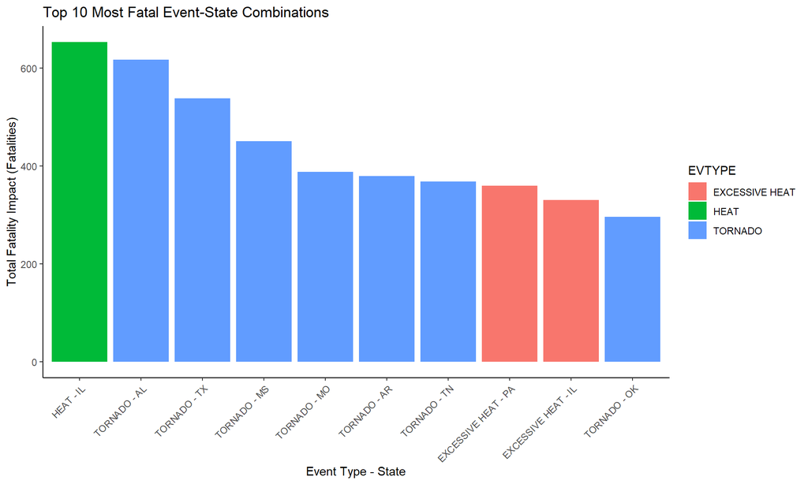

Alarmingly shows which weather events are deadliest including which state it occurs within, this is because including state may shed light on actions to take, for example developing measures to combat heatstroke in a colder climate up north in the United States wouldn’t make too much sense. It is a very large country, hence including the state is pertinent information.

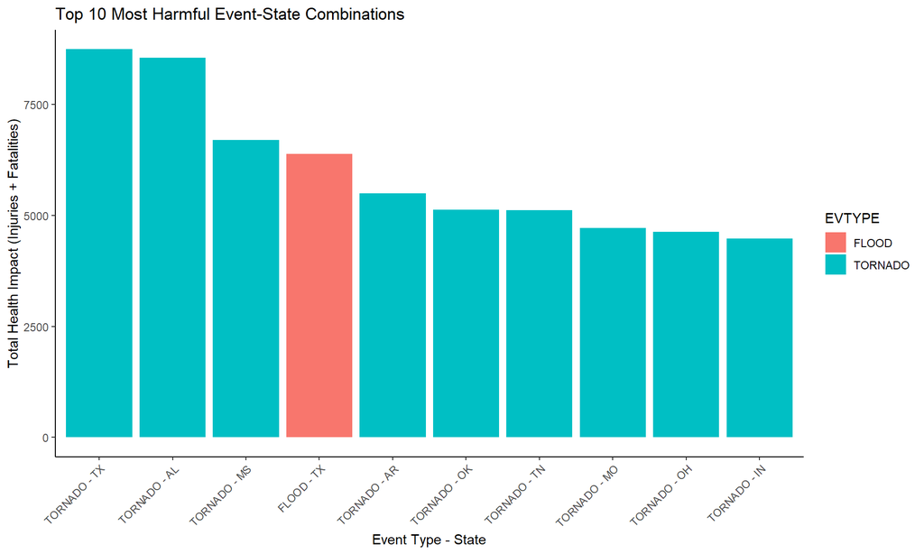

This takes the top 10 most harmful events but includes states to see how weather effects United States across the country, note that this is hard capped to only 10 instead of having 10 for each as this is more interpretable.

## Conclusion

Overall there is a clear separation of which weather events impact the economy the most and which weather events are more detrimental to human life. This may cause a conflict of interest as policy makers now potentially have to balance measures to either prepare for economically impactful events or prioritize human life. Recommendations for future research should be to see which measures can protect both human life and defend against economic hardships if possible. This is no easy task, but innovative solutions may possibly come forth which may help against both. One such measure to me would be to have a very advanced warning system, such a system should be able to determine the formation or likely formation of an amalgamation of events such as excessive heat or tornadoes, floods as these events may have common properties which can be measured early on to prepare civilians and businesses against such events.